# Causes of Complete Networks

2018-09-09T00:00:00Z

# Introduction

Social scientists are often interested in why we observe specific social networks. For example, they would like to answer the question why many complete social networks in real life have small-world-properties. More generally, social scientists aim to explain three aspects of (complete) social networks:

1. structure (the relations in the network)
2. composition (characteristics of the nodes in the network)
3. stability / change / evolution processes (change in the relations or in node-attributes)

We could add more categories in which these aspects are combined, for example to explain why we observe specific network structures (e.g. reciprocated dyads) more among dyads with a specific composition (e.g. among dyads with a similar ethnic background). I will discuss these three aspects, or types of dependent variables, below. Theories to explain these network aspects depend of course on the type of relation(s) under consideration.

## Network structures

### Node-level

Although one node is not a network (the smallest network is a dyad), I would like to start with the node-level.

#### degree

Some nodes, or people in the network will have a higher outdegree than others. See Figure 1 below.

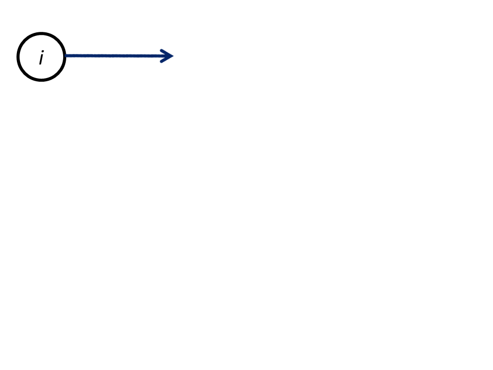

**Figure 1.** Outdegree

We could use the function `degree` in `igraph` to find the outdegree of each node. See below for an example.

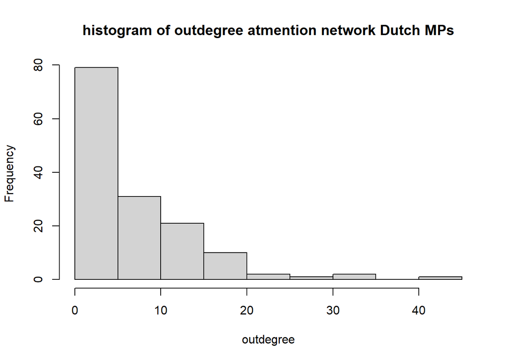

```r
hist(igraph::degree(G1, mode="out", loops=FALSE), xlab="outdegree", main="histogram of outdegree atmention network Dutch MPs")
```

We observe that most MPs atmention a little and some atmention a lot. An explanation could be that some MPs have the ‘task’ (e.g. communication officer) to tweet a lot.

Similarly, as outdegree, some nodes, or people in the network will have a higher indegree than others. See Figure 2 below.

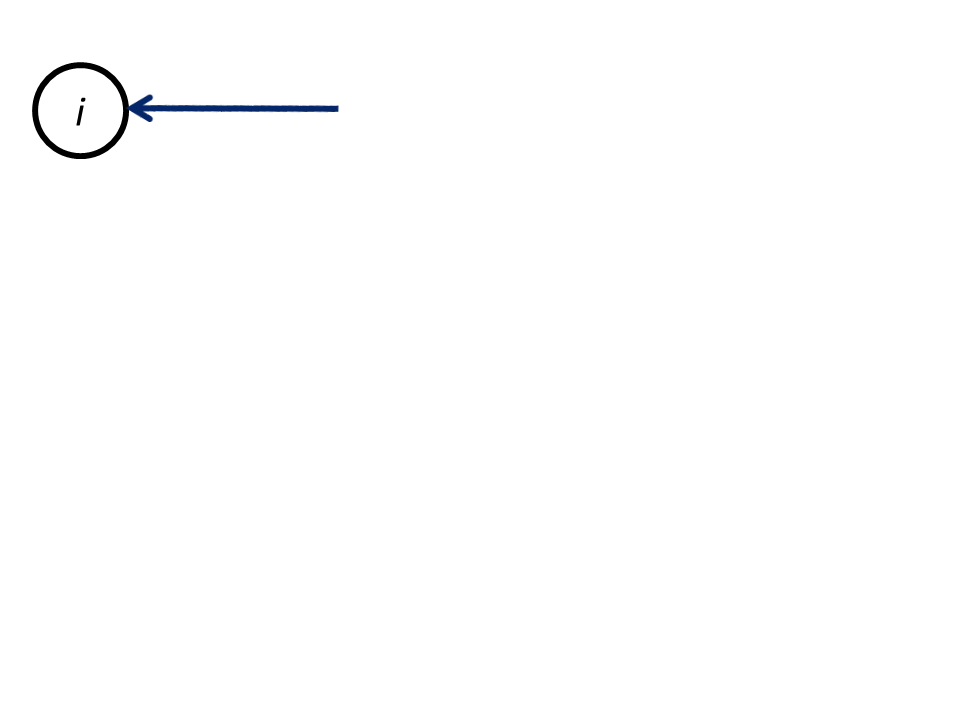

**Figure 2.** Indegree

We could use the function `degree` in `igraph` to find the indegree of each node. See below for an example.

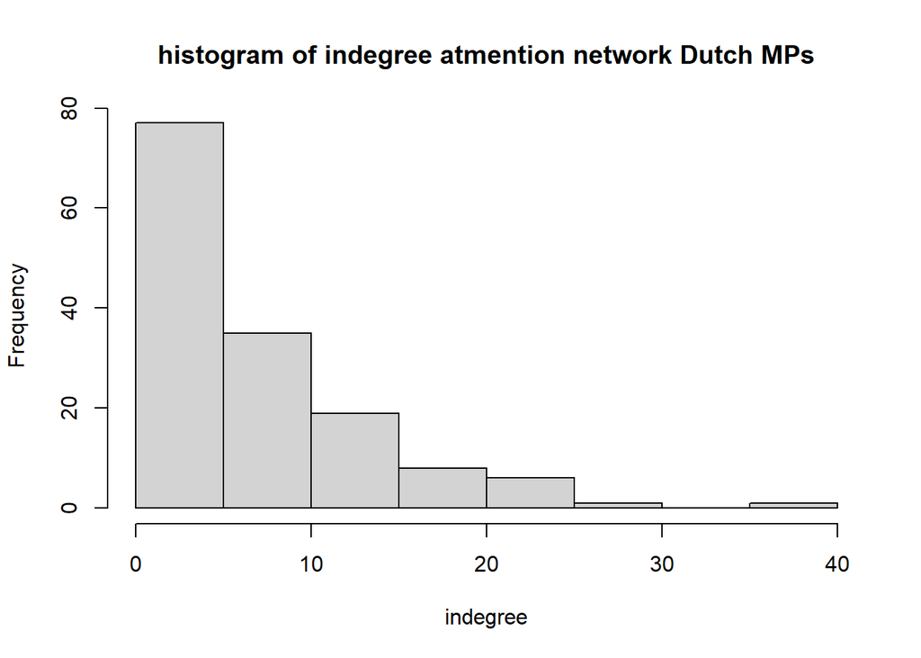

```r
hist(igraph::degree(G1, mode="in", loops=FALSE), xlab="indegree", main="histogram of indegree atmention network Dutch MPs")
```

We observe that most MPs are atmentioned seldom and some are atmentioned often. An explanation could be that some MPs are more important and it may help your own career to atmention thes MPs.

In general, we observe that in many social networks the degree distribution is skewed.

### Dyad-level

#### Undirected Dyads

Dyads are the smalles possible networks. And we have discussed dyads quite extensively here. But just a quick recap. For undirected relations there are two possible dyad configurations. See Figure 3.

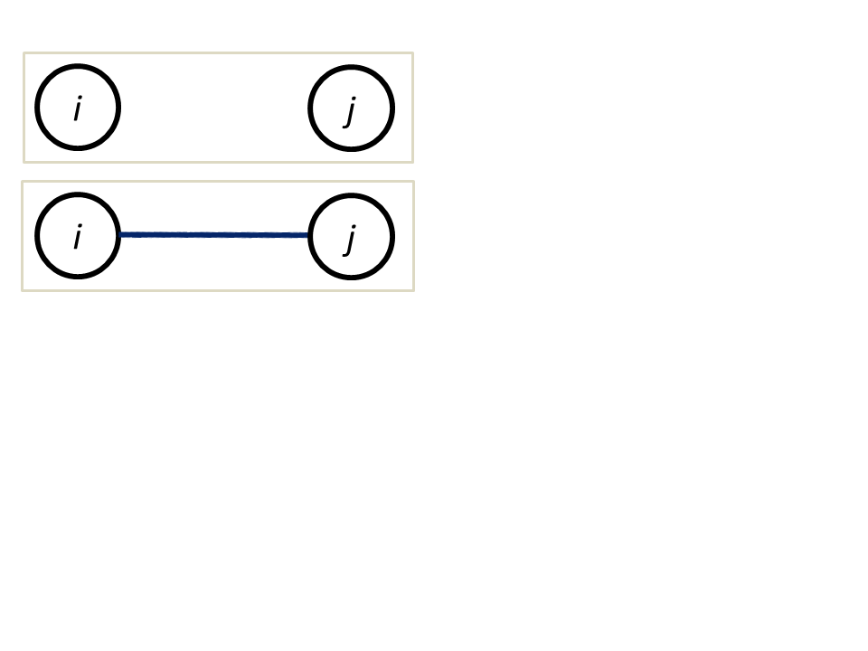

**Figure 3.** Undirected dyads configurations

#### Directed Dyads

And for directed dyads. There are four options. See Figure 4. However, two configurations (the two in the middle row) are *isomorphic*. We cannot distinguish them in the network. From now on, I won’t draw all isomorphs.

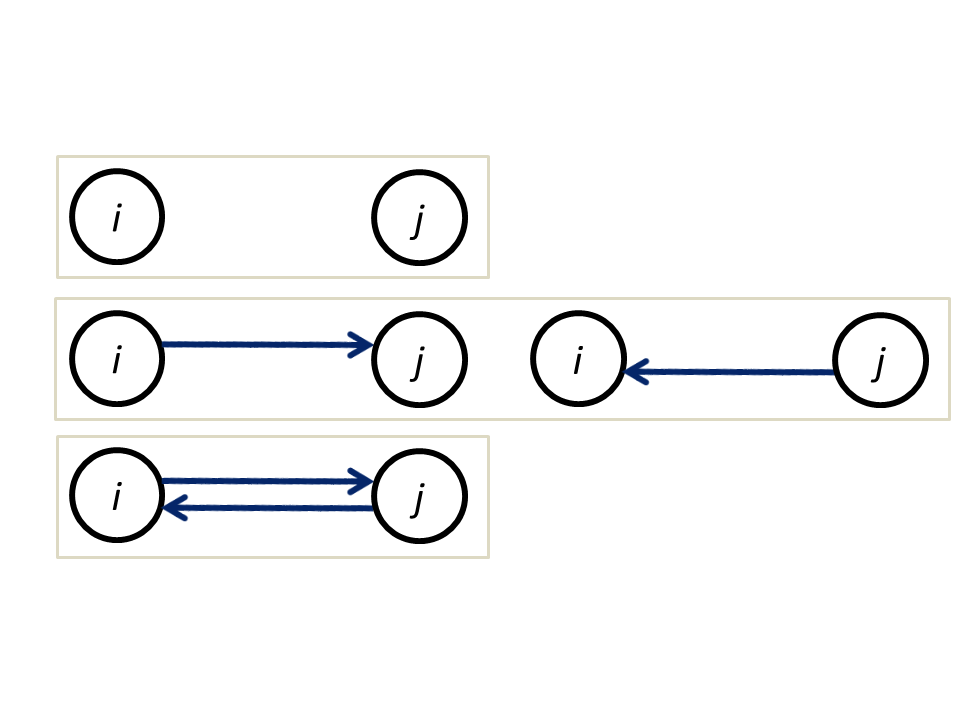

**Figure 4.** Directed dyads configurations

When there is a tie from *i* to *j* and vice versa, we call this a reciprocated dyad. I hope you see that the reasons for me to start or break a relation with you if you don’t have relation with me, may be different from the reasons for me to start or break a relation with you if you have relation with me. Consider the example of atmentioning among MPs. If MP *i* atmentions MP *j* this may increase the visibility of MP *j* on Twitter and this is something MP *j* probably evaluates positively. In return of this favor, MP *j* may atmention MP *j* another time. If I scratch your back, you scratch mine.  
We could use igraph to make a dyad count, which is called a dyad census. See below:

```r
dyadcount <- dyad.census(G1)
dyadcount$total <- (vcount(G1)*(vcount(G1)-1))/2
dyadcount
```

[output not shown]

We could compare these values with a random graph of the same size with the same density.

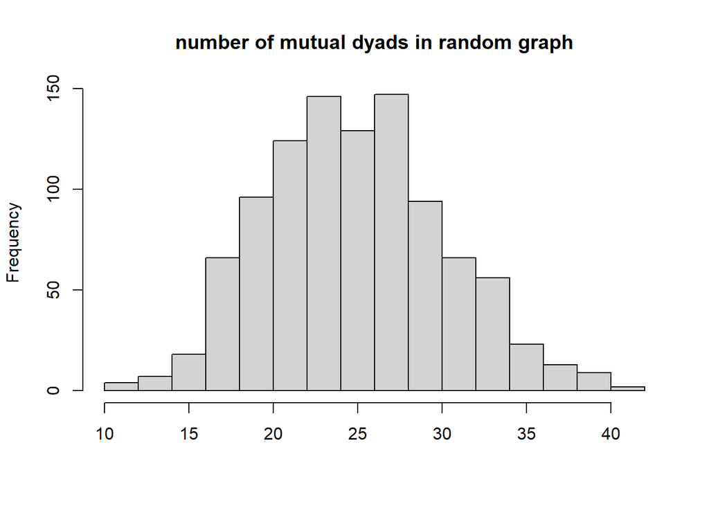

```r
dens <- graph.density(G1)
size <- vcount(G1)
trial <- 1000

recip <- rep(NA, trial)


for ( i in 1:trial ){
  random_graph <- erdos.renyi.game(n = size, p.or.m = dens, directed = TRUE)
  recip[i] <- dyad.census(random_graph)$mut
}

{hist(recip, main="number of mutual dyads in random graph", xlab="", )
abline(v=dyadcount$mut, col="red", lwd=3)}
```

We thus observe way more (or significantly more) mutual dyads (203) as could be expected based solely on chance. Conclusion: MPs scratch each others back.

#### Undirected Dyads - multiplexity

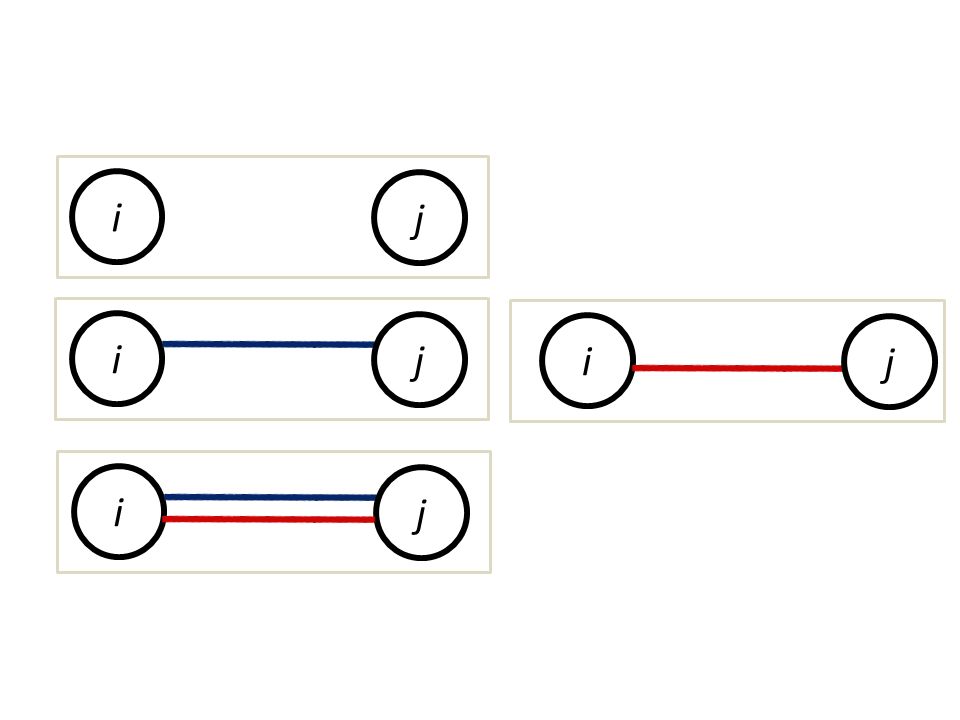

**Figure 5.** Multiplex, undirected dyads configurations

Explanations for multiplex configuration are multicomplex. A first step to consider is whether there is a necessary or likely order in the relations. To illustrate. I first became friends with my wife and afterwards she became my wife. Although this situations hopefully holds true for most married couples, it is not logically necessary of course. A second step is to consider the valence of the relations. Are they positive or negative. It is not likely that I would name my friend a foe and vice versa but there is a thin line between love and hate. Feelings of hate and love for the same person may even coexist. Ever heard someone saying: “I can’t live with him/her but I can’t live without him/her either”?.

#### Directed Dyads - Multiplexity

Lets have a look at the possible configuration of directed dyads with two types of relations (Figure 6)

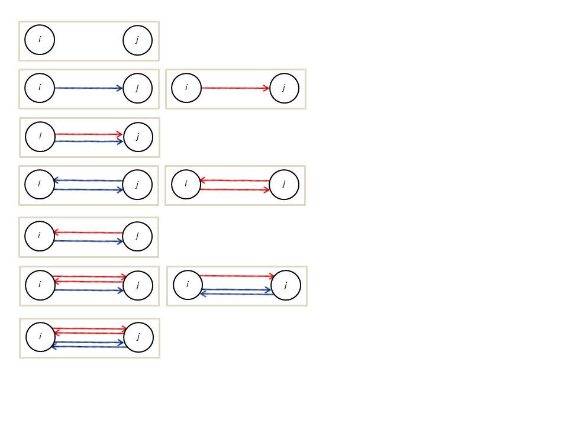

**Figure 6.** Multiplex, directed dyads configurations

### Triad-level

#### Undirected Triads

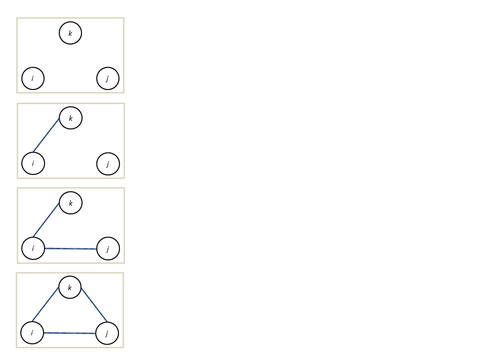

**Figure 7.** Undirected triad configurations

#### Undirected Triads - Multiplexity

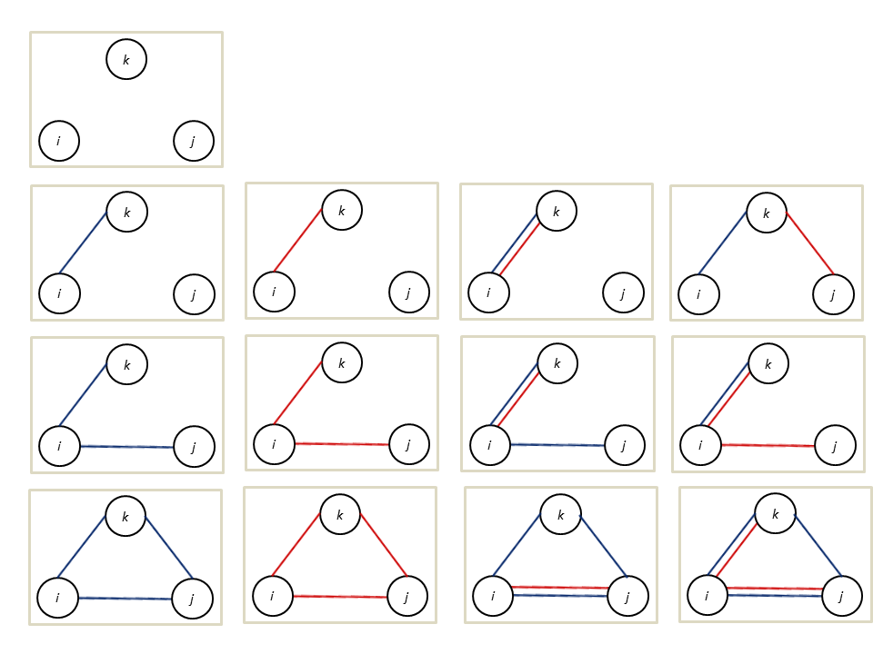

**Figure 8.** Multiplex, undirected triad configurations

#### Directed Triads

By now, I am a bit tired of drawing all these nodes and relations. Luckily, the net is full of pictures of the possible directed triad configurations. I stole the one below from here.

[figure not shown]

**Figure 9.** Directed triad configurations

These triads all have unique names. Depending on the number dyads without ties (last digit), the number of dyads with one tie, or the number of assymetric dyads (second digit) and the number of dyads with two ties, or mutual dyads (first digit). The subtypes are distinguished by the letters C, D, U, T.

This triad census has been developed by Davis and Leinhardt in 1972[^1] And their original picture in the paper is too cool not to show here:

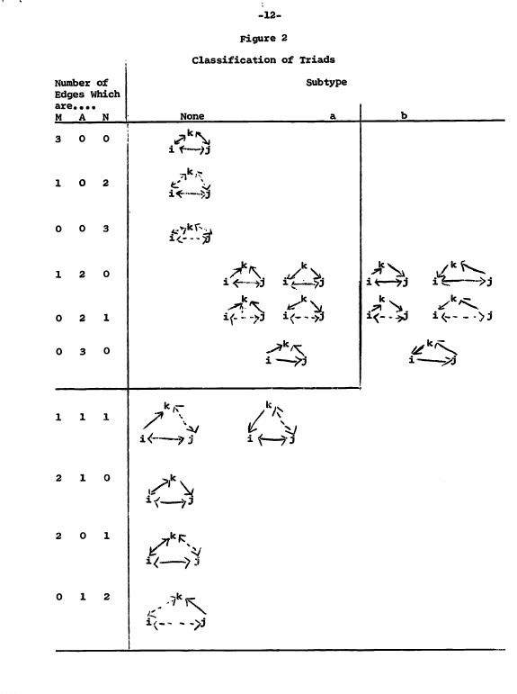

**Figure 9.** Original Triad census by Davis and Leinhard (1972)

[^1] Davis, J.A. and Leinhardt, S. (1972). “The Structure of Positive Interpersonal Relations in Small Groups.” In J. Berger (Ed.), *Sociological Theories in Progress*, Volume 2, 218-251. Boston: Houghton Mifflin. pdf

#### Directed Triads - Multiplexity

## Composition (and structures)

## Stability, Evolution (and structures)